# Pokemon Analysis

# Introduction

## Introduction to Pokemon

Pokemon is a series of video games published by Nintendo where a player can take an adventure through their region. While on your adventure, you will encounter many Pokemon and have the opportunity to both capture and battle them.

In this project, we will explore the various traits and attributes of pokemon, and dive into predicting which Pokemon will win in a battle against other Pokemon.

We will use this dataset found on Kaggle: https://www.kaggle.com/rounakbanik/pokemon

*Note: I found that this dataset does not have ALL Pokemon, so results may be inaccurate due to missing information.*

## Libraries Needed

```r
library(tidyverse)
library(dplyr)
library(ggplot2)
library(reshape2)
```

## Loading the Dataset:

```r
# We will begin with pokemon.csv first and do some EDA on the file
pokemon <- read_csv('pokemon.csv')
head(pokemon)
```

| Number | Name | Type 1 | Type 2 | Abilities | HP | Att | Def | Spa | Spd | Spe | BST | Mean | Standard Deviation | Generation | Experience type | Experience to level 100 | Final Evolution | Catch Rate | Legendary | Mega Evolution | Alolan Form | Galarian Form | Against Normal | Against Fire | Against Water | Against Electric | Against Grass | Against Ice | Against Fighting | … |
| --- | --- | --- | --- | --- | --- | --- | --- | --- | --- | --- | --- | --- | --- | --- | --- | --- | --- | --- | --- | --- | --- | --- | --- | --- | --- | --- | --- | --- | --- | --- |
| 1 | Bulbasaur | Grass | Poison | ['Chlorophyll', 'Overgrow'] | 45 | 49 | 49 | 65 | 65 | 45 | 318 | 53.0000 | 8.640988 | 1 | Medium Slow | 1059860 | 0 | 45 | 0 | 0 | 0 | 0 | 1 | 2.0 | 0.5 | 0.5 | 0.25 | 2.0 | 0.5 | … |
| 2 | Ivysaur | Grass | Poison | ['Chlorophyll', 'Overgrow'] | 60 | 62 | 63 | 80 | 80 | 60 | 405 | 67.5000 | 8.902247 | 1 | Medium Slow | 1059860 | 0 | 45 | 0 | 0 | 0 | 0 | 1 | 2.0 | 0.5 | 0.5 | 0.25 | 2.0 | 0.5 | … |
| 3 | Venusaur | Grass | Poison | ['Chlorophyll', 'Overgrow'] | 80 | 82 | 83 | 100 | 100 | 80 | 525 | 87.5000 | 8.902247 | 1 | Medium Slow | 1059860 | 1 | 45 | 0 | 0 | 0 | 0 | 1 | 2.0 | 0.5 | 0.5 | 0.25 | 2.0 | 0.5 | … |
| 3 | Mega Venusaur | Grass | Poison | ['Thick Fat'] | 80 | 100 | 123 | 122 | 120 | 80 | 625 | 104.1667 | 18.747592 | 6 | Medium Slow | 1059860 | 1 | 45 | 0 | 1 | 0 | 0 | 1 | 2.0 | 0.5 | 0.5 | 0.25 | 2.0 | 0.5 | … |
| 4 | Charmander | Fire | NA | ['Blaze', 'Solar Power'] | 39 | 52 | 43 | 60 | 50 | 65 | 309 | 51.5000 | 8.995369 | 1 | Medium Slow | 1059860 | 0 | 45 | 0 | 0 | 0 | 0 | 1 | 0.5 | 2.0 | 1.0 | 0.50 | 0.5 | 1.0 | … |
| 5 | Charmeleon | Fire | NA | ['Blaze', 'Solar Power'] | 58 | 64 | 58 | 80 | 65 | 80 | 405 | 67.5000 | 9.233093 | 1 | Medium Slow | 1059860 | 0 | 45 | 0 | 0 | 0 | 0 | 1 | 0.5 | 2.0 | 1.0 | 0.50 | 0.5 | 1.0 | … |

Since each column has spaces, we want to reformat it so it will be easier to perform data analysis on them.

```r
names(pokemon) <- gsub(" ", "_", names(pokemon))
names(pokemon) <- gsub("\\.", "", names(pokemon))
names(pokemon) <- tolower(names(pokemon))
head(pokemon)
```

| number | name | type_1 | type_2 | abilities | hp | att | def | spa | spd | spe | bst | mean | standard_deviation | generation | experience_type | experience_to_level_100 | final_evolution | catch_rate | legendary | mega_evolution | alolan_form | galarian_form | against_normal | against_fire | against_water | against_electric | against_grass | against_ice | against_fighting | … |
| --- | --- | --- | --- | --- | --- | --- | --- | --- | --- | --- | --- | --- | --- | --- | --- | --- | --- | --- | --- | --- | --- | --- | --- | --- | --- | --- | --- | --- | --- | --- |
| 1 | Bulbasaur | Grass | Poison | ['Chlorophyll', 'Overgrow'] | 45 | 49 | 49 | 65 | 65 | 45 | 318 | 53.0000 | 8.640988 | 1 | Medium Slow | 1059860 | 0 | 45 | 0 | 0 | 0 | 0 | 1 | 2.0 | 0.5 | 0.5 | 0.25 | 2.0 | 0.5 | … |
| 2 | Ivysaur | Grass | Poison | ['Chlorophyll', 'Overgrow'] | 60 | 62 | 63 | 80 | 80 | 60 | 405 | 67.5000 | 8.902247 | 1 | Medium Slow | 1059860 | 0 | 45 | 0 | 0 | 0 | 0 | 1 | 2.0 | 0.5 | 0.5 | 0.25 | 2.0 | 0.5 | … |
| 3 | Venusaur | Grass | Poison | ['Chlorophyll', 'Overgrow'] | 80 | 82 | 83 | 100 | 100 | 80 | 525 | 87.5000 | 8.902247 | 1 | Medium Slow | 1059860 | 1 | 45 | 0 | 0 | 0 | 0 | 1 | 2.0 | 0.5 | 0.5 | 0.25 | 2.0 | 0.5 | … |
| 3 | Mega Venusaur | Grass | Poison | ['Thick Fat'] | 80 | 100 | 123 | 122 | 120 | 80 | 625 | 104.1667 | 18.747592 | 6 | Medium Slow | 1059860 | 1 | 45 | 0 | 1 | 0 | 0 | 1 | 2.0 | 0.5 | 0.5 | 0.25 | 2.0 | 0.5 | … |
| 4 | Charmander | Fire | NA | ['Blaze', 'Solar Power'] | 39 | 52 | 43 | 60 | 50 | 65 | 309 | 51.5000 | 8.995369 | 1 | Medium Slow | 1059860 | 0 | 45 | 0 | 0 | 0 | 0 | 1 | 0.5 | 2.0 | 1.0 | 0.50 | 0.5 | 1.0 | … |
| 5 | Charmeleon | Fire | NA | ['Blaze', 'Solar Power'] | 58 | 64 | 58 | 80 | 65 | 80 | 405 | 67.5000 | 9.233093 | 1 | Medium Slow | 1059860 | 0 | 45 | 0 | 0 | 0 | 0 | 1 | 0.5 | 2.0 | 1.0 | 0.50 | 0.5 | 1.0 | … |

# Exploratory Data Analysis

Let’s begin by exploring each Pokemon type.

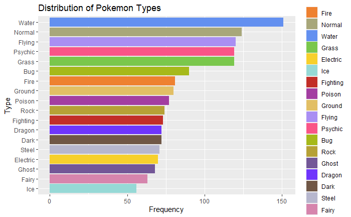

We see that Water is the most frequent Pokemon type, with Ice being the least frequent.

Now, let’s explore different type combinations and see which of them are the most popular.

```r
combinations = table(pokemon$type_1, pokemon$type_2) + table(pokemon$type_2, pokemon$type_1)
combinations_df = as.data.frame(combinations)
```

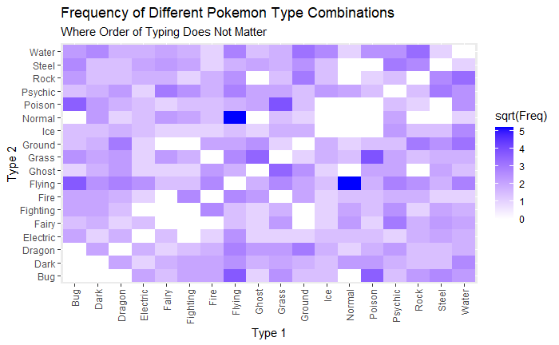

```r
ggplot(data = combinations_df, aes(x = Var1, y = Var2, fill = sqrt(Freq))) + geom_tile() + scale_fill_gradient2(low = "white", high = "blue") + labs(x = "Type 1", y = "Type 2", title = "Frequency of Different Pokemon Type Combinations", subtitle = "Where Order of Typing Does Not Matter") + theme(axis.text.x = element_text(angle = 90, vjust = 0.5, hjust=1))
```

We see that the Normal/Flying Pokemon type combination is the most common. It’s also interesting to note that there are a lot of type combinations that haven’t been produced yet. Let’s get a list of all the type combinations that haven’t been made yet, and it’ll give Nintendo an idea of what new Pokemon they could make.

```r
not_produced <- subset(x = combinations_df, subset = (Freq == 0 & Var1 != Var2))
nrow(not_produced)
```

```
[1] 34
```

Now we wonder: What would be the effectiveness of each of these type combinations if they were added to the game?

To do this, we will measure each combination’s weaknesses and strengths, and see if any of them are stronger or weaker than normal.

We will use a chart of type weaknesses and strengths, found on: https://github.com/zonination/pokemon-chart/blob/c6c3d4e982e9f6d49055dcfd396a148da1c6cd2b/chart.csv